# Assignment1_knitr

Author: Anna Lüber Date Created: November 10 2022

## Loading and preprocessing the data

I am showing any code that is needed to load the data (i.e.read.csv()

```r
library(data.table)
library(dplyr)
```

```r
library(ggplot2)

# fast loading zip file
dt <- data.table::fread(unzip("activity.zip"), fill=TRUE)
# Inspect data
str(dt)
```

```
## Classes 'data.table' and 'data.frame':   17568 obs. of  3 variables:
##  $ steps   : int  NA NA NA NA NA NA NA NA NA NA ...
##  $ date    : IDate, format: "2012-10-01" "2012-10-01" ...
##  $ interval: int  0 5 10 15 20 25 30 35 40 45 ...
##  - attr(*, ".internal.selfref")=<externalptr>
```

NA’s will be ignored for now.

## What is mean total number of steps taken per day?

I calculate the total number of steps taken per day and make a histogram of the total number of steps taken each day. Additionally, I calculate and report the mean and median of the total number of steps taken per day

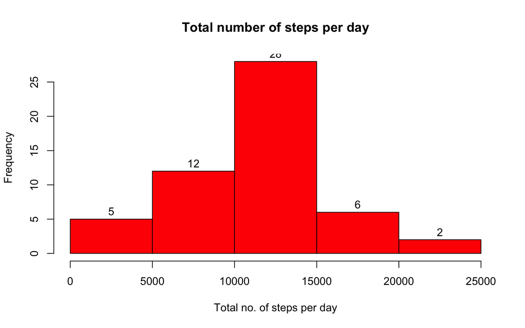

```r
# grouping and summarizing
stepsperday <- dt %>%
    group_by(date) %>%
    summarize(sumsteps = sum(steps),  .groups = 'drop')

# plotting histogram
with(stepsperday,
    hist(sumsteps,
        xlab = "Total no. of steps per day",
        main = "Total number of steps per day",
        col = "red",
        border = "black",
        labels = TRUE))
```

```r
# mean and median via filtering and summarizing

mm<- stepsperday %>%filter(complete.cases(.)) %>%
    summarize(mean = mean(sumsteps), median = median(sumsteps))
```

The mean total no. of steps is 1.0766189^{4} and the median is 10765.

## What is the average daily activity pattern?

I make a time series plot of the 5-minute interval (x-axis) and the average number of steps taken, averaged across all days (y-axis).

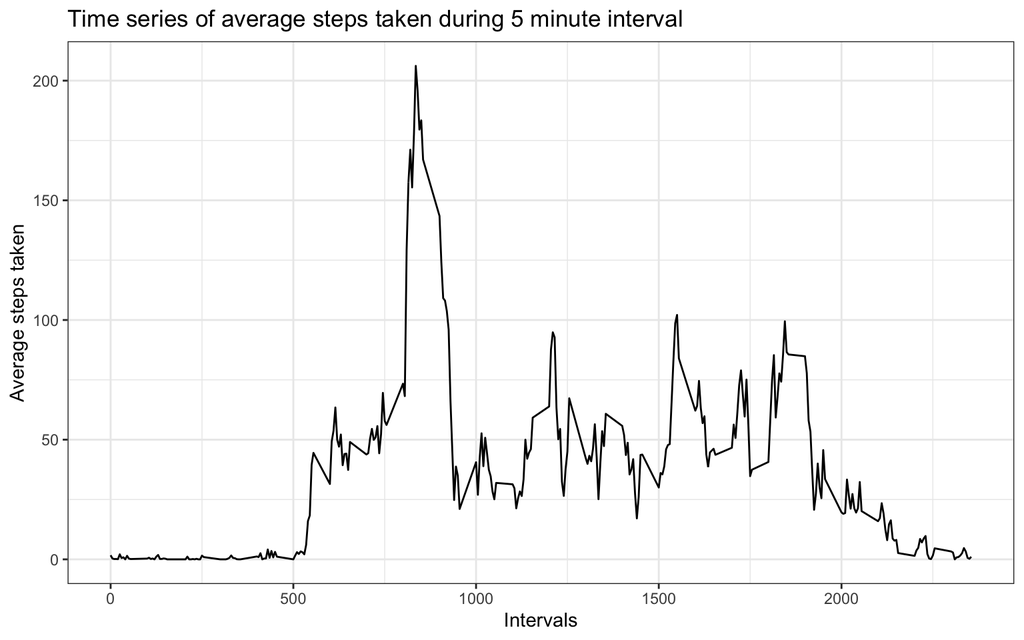

```r
# summarize data first
mean_interval <- dt %>% group_by(interval) %>%
  # remove NA'a
    na.omit() %>% summarize(avg_step = mean(steps), .groups = 'drop')

# make a nice plot
ggplot(mean_interval, aes(interval, avg_step)) +
    geom_line() +
    labs(x = "Intervals", y = "Average steps taken") +
    ggtitle("Time series of average steps taken during 5 minute interval") +
    theme_bw()
```

```r
# find max number of steps by filtering!
maximum<- mean_interval %>% filter(avg_step == max(avg_step))
```

## Imputing missing values

The presence of missing days may introduce bias into some calculations or summaries of the data. Thus, I calculate and report the total number of missing values in the dataset (i.e. the total number of rows with NAs)

I create a new dataset that is equal to the original dataset but with the missing data filled in! Then, I make a histogram of the total number of steps taken each day and I calculate and report the mean and median total number of steps taken per day.

```r
# To find total missing values:
missing <- dt %>% summarise_all(~sum(is.na(.)))

# create new data table
complete_dt <- dt
# loop over all rows
for (i in 1:nrow(complete_dt)) {
    if(is.na(complete_dt$steps[i])) {
        # match indexes of new datatable interval with mean_interval
        index <- which(complete_dt$interval[i] == mean_interval$interval)
        # assign average step to NA at ith row of step column
        complete_dt$steps[i] <- mean_interval[index,]$avg_step}}
```

The steps column has a total of 2304` missing values, whereas the date and interval column have none. With the new data table complete_dt from above, I create a new histogram.

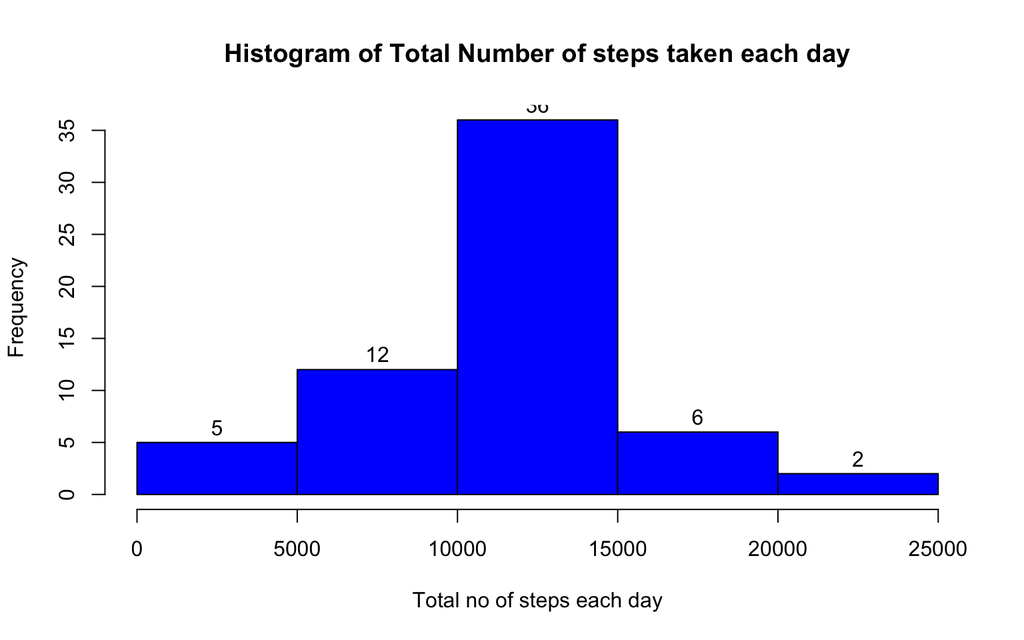

```r
# perform necessary transformation
hist_complete_dt <- complete_dt %>%
    group_by(date) %>%
    summarize(sumsteps = sum(steps), .groups = 'drop')

# plot histogram
with(hist_complete_dt,
    hist(sumsteps,
        xlab = "Total no of steps each day",
        main = "Histogram of Total Number of steps taken each day",
        col = "blue",
        border = "black",
        labels = TRUE))
```

```r
mm2<- hist_complete_dt %>%
    summarize(mean = mean(sumsteps), median = median(sumsteps))
```

The mean and median calculated with the new dataset is now identical:

1.0766189^{4}, 1.0766189^{4}`

## Are there differences in activity patterns between weekdays and weekends?

I use the dataset with the filled-in missing values for this part and create a new factor variable in the dataset with two levels – “weekday” and “weekend” indicating whether a given date is a weekday or weekend day. Then, I make a panel plot containing a time series plot of the 5-minute interval (x-axis) and the average number of steps taken, averaged across all weekday days or weekend days (y-axis).

```r
# load library
library(chron)
```

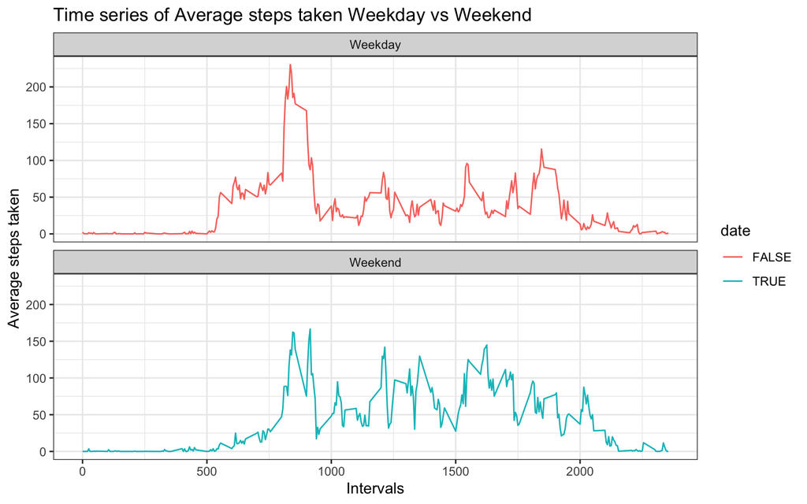

```r
w_complete_dt <- complete_dt %>%
    mutate(date = chron::is.weekend(date))

## for time series: transforming data for plotting
w_timeseries <- w_complete_dt %>% group_by(date, interval) %>%
    summarize(avg_step = mean(steps), .groups = 'drop')
# changing labels for more appropriate names
labels <- as_labeller(c(`TRUE` = "Weekend", `FALSE` = "Weekday"))

# plot nice time series plot
ggplot(w_timeseries, aes(interval, avg_step, color=date)) +
    geom_line() +
    facet_wrap(~date, nrow=2, labeller= labels)+
    labs(x = "Intervals", y = "Average steps taken") +
    ggtitle("Time series of Average steps taken Weekday vs Weekend") +
    theme_bw()
```